# İsim: Muhammet Fatih

# Eğitim Verisi Üzerinden Tahmin (In-Sample Prediction)

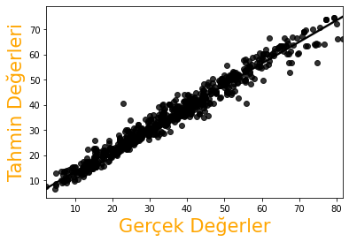

```python
y_tahmin_bagg=bagg_model0.predict(X_egitim)

fig, ax = mpl.subplots()
sb.regplot(y_egitim, y_tahmin_bagg, color="black")
ax.set_ylabel("Tahmin Değerleri", fontsize=21, color="orange")
ax.set_xlabel("Gerçek Değerler", fontsize=21, color="orange")
```

```python
print(" R2 Değeri: ",r2_score(y_egitim, y_tahmin_bagg),"\n","MSE Değeri: ",mean_squared_error(y_egitim,y_tahmin_bagg))
```

```
 R2 Değeri:  0.9531860441067457
 MSE Değeri:  13.377340589917685
```

### R2 değerine göre, bağımlı değişkendeki toplam değişimin %95'i bağımsız değişkenlerdeki değişimle açıklanabilmiştir.

### MSE değerine göre, tahmin edilen değerler gerçek değerlere çok yakındır.

### Modelin performansı çok iyi seviyededir.

# Model Optimizasyonu

```python
bag_params= {"n_estimators": range(10,100)}
GS_bag= GridSearchCV(bagg_model0, bag_params, cv=10).fit(X_egitim, y_egitim)
GS_bag.best_params_
```

```
{'n_estimators': 87}
```

# En İyi Parametre Değeriyle Modelin Kurulması

```python
best_bagg_model=BaggingRegressor(n_estimators=87,bootstrap_features=(True)).fit(X_egitim,y_egitim)
```

# Eğitim Verisi Üzerinden Tahmin (In-Sample Prediction)

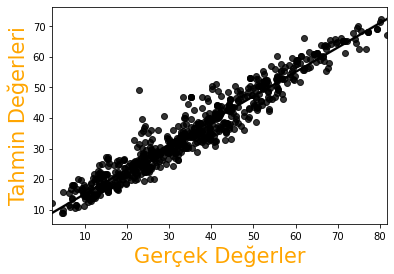

```python
y_tahmin_best_bagg=best_bagg_model.predict(X_egitim)

fig, ax = mpl.subplots()
sb.regplot(y_egitim, y_tahmin_best_bagg, color="black")
ax.set_ylabel("Tahmin Değerleri", fontsize=21, color="orange")
ax.set_xlabel("Gerçek Değerler", fontsize=21, color="orange")
```

```python
print(" R2 Değeri: ",r2_score(y_egitim,y_tahmin_best_bagg),"\n","MSE Değeri:",mean_squared_error(y_egitim,y_tahmin_best_bagg))
```

```
 R2 Değeri:  0.909907266643699
 MSE Değeri: 25.744484861138197
```

### Grafik incelendiğinde, modelin çok iyi tahmin performansı olduğu görülüyor. R2 ve MSE değerleri çok iyi.

### R2 değerine göre, bağımlı değişkendeki toplam değişimin %90'ı bağımsız değişkenler tarafından açıklanabilmiştir.

### MSE değerine göre, tahmin edilen değerler gerçek değerlere çok yakındır.

# Test Verisi Üzerinden Tahmin (Out-Of-Sample Prediction)

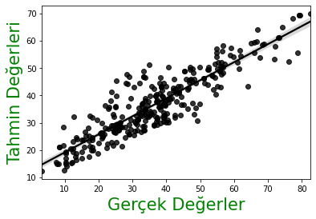

```python
y_hat_best_bagg=best_bagg_model.predict(X_test)

fig, ax = mpl.subplots()
sb.regplot(y_test, y_hat_best_bagg, color="black")
ax.set_ylabel("Tahmin Değerleri", fontsize=21, color="green")
ax.set_xlabel("Gerçek Değerler", fontsize=21, color="green")
```

```python
print(" R2 Değeri: ",r2_score(y_test,y_hat_best_bagg),"\n","MSE Değeri:",mean_squared_error(y_test,y_hat_best_bagg))
```

```
 R2 Değeri:  0.776604720658567
 MSE Değeri: 58.553510941002706
```

### Grafik incelendiğinde, modelin out-of-sample prediction sonucu da iyi olduğu görülüyor. R2 ve MSE değerleri iyi.

### R2 değerine göre, bağımlı değişkendeki toplam değişimin %77'si bağımsız değişkenler tarafından açıklanabilmiş.

### MSE değerine göre, tahmin edilen değerler gerçek değerlere yakındır.

### Modelin performansı iyi seviyededir.

# Random Forest

# Modelin Kurulması

```python
rf_model=RandomForestRegressor().fit(X_egitim, y_egitim)
```

# Eğitim Verisi Üzerinden Tahmin (In-Sample Prediction)

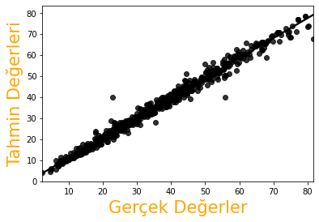

```python
y_tahmin_rf= rf_model.predict(X_egitim)

fig, ax = mpl.subplots()
sb.regplot(y_egitim, y_tahmin_rf, color="black")
ax.set_ylabel("Tahmin Değerleri", fontsize=21, color="orange")
ax.set_xlabel("Gerçek Değerler", fontsize=21, color="orange")
```

```python
print(" R2 Değeri: ",r2_score(y_egitim,y_tahmin_rf),"\n","MSE Değeri:",mean_squared_error(y_egitim,y_tahmin_rf))
```

```
 R2 Değeri:  0.9841874833236369
 MSE Değeri: 4.518511993427631
```

### Grafik incelendiğinde, modelin çok iyi tahmin yaptığı görülüyor. R2 ve MSE değeleri çok iyi.

### R2 değerine göre, bağımlı değişkendeki toplam değişimin %98'i bağımsız değişkenler tarafından açıklanabilmiştir.

### MSE değerine göre, tahmin edilen değerler gerçek değerlere çok yakındır.

### Modelin performansı çok iyi seviyededir.

# Model Optimizasyonu

```python
rf_params = {"max_depth": range(5,20),"max_features": [2,3,5,7,9,15], "n_estimators": [50,75,100,110,125,150,175,200]}
GS_rf= GridSearchCV(rf_model, rf_params, cv=5).fit(X_egitim, y_egitim)
GS_rf.best_params_
```

```
{'max_depth': 18, 'max_features': 5, 'n_estimators': 150}
```

# En İyi Parametre Değerleriyle Modelin Kurulması

```python
rf_optimum= RandomForestRegressor(max_depth=18, max_features=5, n_estimators=150).fit(X_egitim, y_egitim)
```

# Eğitim Verisi Üzerinden Tahmin (In-Sample Prediction)

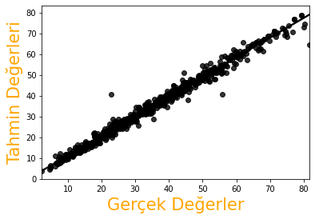

```python
y_tahmin_optimum_rf= rf_optimum.predict(X_egitim)

fig, ax = mpl.subplots()
sb.regplot(y_egitim, y_tahmin_optimum_rf, color="black")
ax.set_ylabel("Tahmin Değerleri", fontsize=21, color="orange")
ax.set_xlabel("Gerçek Değerler", fontsize=21, color="orange")
```

```python
print(" R2 Değeri: ",r2_score(y_egitim,y_tahmin_optimum_rf),"\n","MSE Değeri:",mean_squared_error(y_egitim,y_tahmin_optimum_rf))
```

```
 R2 Değeri:  0.9844440409087013
 MSE Değeri: 4.445199278643217
```

### Grafik incelendiğinde, modelin çok iyi tahmin yaptığı görülüyor. R2 ve MSE değerleri çok iyi.

### R2 değerine göre, bağımlı değişkendeki toplam değişimin %98'i bağımsız değişkenler tarafından açıklanabilmiştir.

### MSE değerine göre, tahmin edilen değerler gerçek değerlere çok yakındır.

### Modelin performansı çok iyi seviyededir.

# Test Verisi Üzerinden Tahmin (Out-Of-Sample Prediction)

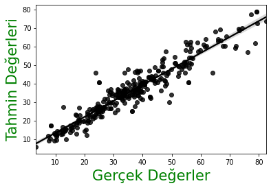

```python
y_hat_optimum_rf= rf_optimum.predict(X_test)

fig, ax = mpl.subplots()
sb.regplot(y_test, y_hat_optimum_rf, color="black")
ax.set_ylabel("Tahmin Değerleri", fontsize=21, color="green")
ax.set_xlabel("Gerçek Değerler", fontsize=21, color="green")
```

```python
print(" R2 Değeri: ",r2_score(y_test,y_hat_optimum_rf),"\n","MSE Değeri:",mean_squared_error(y_test,y_hat_optimum_rf))
```

```
 R2 Değeri:  0.8923846952903788
 MSE Değeri: 28.206746088414132
```

### Grafik incelendiğinde, modelin out-of-sample prediction sonucunun da iyi olduğu görülüyor. R2 ve MSE değerleri de iyi.

### R2 değerine göre, bağımlı değişkendeki toplam değişimin %89'u bağımsız değişkenler tarafından açıklanabilmiştir.

### MSE değerine göre, tahmin edilen değerler gerçek değerlere yakındır.

### Modelin performansı iyi seviyededir.

# Gradient Boosting Machines

# Modelin Kurulması

```python
gb_model0 = GradientBoostingRegressor().fit(X_egitim, y_egitim)
```

# Eğitim Verisi Üzerinden Tahmin (In-Sample Prediction)

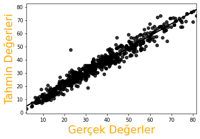

```python
y_tahmin_gb = gb_model0.predict(X_egitim)

fig, ax = mpl.subplots()
sb.regplot(y_egitim, y_tahmin_gb, color="black")
ax.set_ylabel("Tahmin Değerleri", fontsize=21, color="orange")
ax.set_xlabel("Gerçek Değerler", fontsize=21, color="orange")
```

```python
print(" R2 Değeri: ",r2_score(y_egitim,y_tahmin_gb),"\n","MSE Değeri:",mean_squared_error(y_egitim,y_tahmin_gb))
```

```
 R2 Değeri:  0.9527437802952219
 MSE Değeri: 13.503719861322146
```

### Grafik incelendiğinde, modelin çok iyi tahmin yaptığı görülüyor. R2 ve MSE değerleri çok iyi.

### R2 değerine göre, bağımlı değişkendeki toplam değişimin %95'i bağımsız değişkenler tarafından açıklanabilmiştir. MSE değerine göre, tahmin edilen değerler gerçek değerlere çok yakındır.

### Modelin performansı çok iyi seviyededir.

# Model Optimizasyonu

```python
gb_params={"learning_rate": [0.001, 0.05, 0.1, 0.2, 0.5, 0.8], "max_depth":[2,3,5,7,9,10],
           "n_estimators":[75,90,100,110,120,135,150,200], "subsample":[0.5,1]}
GS_gb= GridSearchCV(gb_model0, gb_params, cv=5).fit(X_egitim, y_egitim)
GS_gb.best_params_
```

```
{'learning_rate': 0.2, 'max_depth': 3, 'n_estimators': 200, 'subsample': 1}
```

# En İyi Parametre Değerleriyle Modelin Kurulması

```python
gb_best_model= GradientBoostingRegressor(learning_rate=0.2, max_depth= 3, n_estimators= 200,subsample=1).fit(X_egitim,
                                                                                                         y_egitim)
```

# Eğitim Verisi Üzerinden Tahmin (In-Sample Prediction)

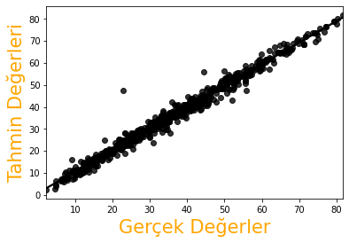

```python
y_tahmin_best_gb = gb_best_model.predict(X_egitim)

fig, ax = mpl.subplots()
sb.regplot(y_egitim, y_tahmin_best_gb, color="black")
ax.set_ylabel("Tahmin Değerleri", fontsize=21, color="orange")
ax.set_xlabel("Gerçek Değerler", fontsize=21, color="orange")
```

```python
print(" R2 Değeri: ",r2_score(y_egitim,y_tahmin_best_gb),"\n","MSE Değeri:",mean_squared_error(y_egitim,y_tahmin_best_gb))
```

```
 R2 Değeri:  0.9840328067833015
 MSE Değeri: 4.5627116497449665
```

### Grafik incelendiğinde, modelin çok iyi tahmin yaptığı görülüyor. R2 ve MSE değerleri de çok iyi. R2 değerinde ve MSE değerinde bir önceki modele göre iyileşme yaşandı.

### R2 değerine göre, bağımlı değişkendeki toplam değişimin %98'i bağımsız değişkenler tarafından açıklanabilmiştir.

### MSE değerine göre, tahmin edilen değerler gerçek değerlere çok yakındır.

### Modelin performansı çok iyi seviyededir.

# Test Verisi Üzerinden Tahmin (Out-Of-Sample Prediction)

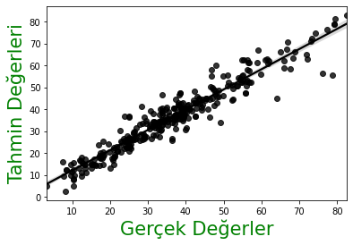

```python
y_hat_best_gb = gb_best_model.predict(X_test)

fig, ax = mpl.subplots()
sb.regplot(y_test, y_hat_best_gb, color="black")
ax.set_ylabel("Tahmin Değerleri", fontsize=21, color="green")
ax.set_xlabel("Gerçek Değerler", fontsize=21, color="green")
```

```python
print(" R2 Değeri: ",r2_score(y_test,y_hat_best_gb),"\n","MSE Değeri:",mean_squared_error(y_test,y_hat_best_gb))
```

```
 R2 Değeri:  0.9169438311276817
 MSE Değeri: 21.769619783908624
```

### Grafik incelendiğinde, modelin out-of-sample prediction'u da iyi görünüyor. R2 ve MSE değerleri de çok iyi.

### R2 değerine göre, bağımlı değişkendeki toplam değişimin %91'i bağımsız değişkenler tarafından açıklanabilmiştir. MSE değerine göre, tahmin edilen değerler gerçek değerlere çok yakındır.

### Modelin performansı çok iyi seviyededir.

# XGBoost

# Modelin Kurulması

```python
xgb_model = XGBRegressor().fit(X_egitim, y_egitim)
```

# Eğitim Verisi Üzerinden Tahmin (In-Sample Prediction)

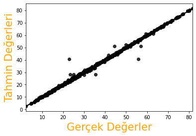

```python
y_tahmin_xgb= xgb_model.predict(X_egitim)

fig, ax = mpl.subplots()
sb.regplot(y_egitim, y_tahmin_xgb, color="black")
ax.set_ylabel("Tahmin Değerleri", fontsize=21, color="orange")
ax.set_xlabel("Gerçek Değerler", fontsize=21, color="orange")
```

```python
print(" R2 Değeri: ",r2_score(y_egitim,y_tahmin_xgb),"\n","MSE Değeri:",mean_squared_error(y_egitim,y_tahmin_xgb))
```

```
 R2 Değeri:  0.9959206367033738
 MSE Değeri: 1.1657000816895462
```

### Grafik incelendiğinde, modelin çok iyi tahmin yaptığı görülüyor. R2 ve MSE değerleri de çok iyi.

### R2 değerine göre, bağımlı değişkendeki toplam değişimin %99'u bağımsız değişkenler tarafından açıklanabilmiştir. MSE değerine göre, tahmin edilen değerler gerçek değerlere çok yakındır.

### Modelin performansı çok iyi seviyededir.

# Model Optimizasyonu

```python
xgb_params= {"colsample_bytree":[0.01,0.05,0.1,0.2,0.3,0.5,0.6,0.75,0.9,1], "n_estimators":[75,100,110,120,135,150,165,175,190,
                                                                                            200,250]}
GS_xgb = GridSearchCV(xgb_model, xgb_params, cv=5).fit(X_egitim, y_egitim)
GS_xgb.best_params_
```

```
{'colsample_bytree': 0.5, 'n_estimators': 100}
```

# En İyi Parametre Değerleriyle Modelin Kurulması

```python
xgb_best = XGBRegressor(colsample_bytree=0.5, n_estimators= 100).fit(X_egitim, y_egitim)
```

# Eğitim Verisi Üzerinden Tahmin (In-Sample Prediction)

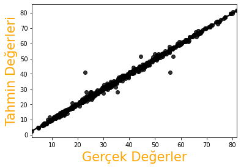

```python
y_tahmin_opt_xgb = xgb_best.predict(X_egitim)

fig, ax = mpl.subplots()
sb.regplot(y_egitim, y_tahmin_opt_xgb, color="black")
ax.set_ylabel("Tahmin Değerleri", fontsize=21, color="orange")
ax.set_xlabel("Gerçek Değerler", fontsize=21, color="orange")
```

```python
print(" R2 Değeri: ",r2_score(y_egitim,y_tahmin_opt_xgb),"\n","MSE Değeri:",mean_squared_error(y_egitim,y_tahmin_opt_xgb))
```

```
 R2 Değeri:  0.9946791338856594
 MSE Değeri: 1.5204662132631774
```

### Grafik incelendiğinde, modelin çok iyi tahmin yaptığı görülüyor. R2 ve MSE değerleri de çok iyi.

### R2 değerine göre, bağımlı değişkendeki toplam değişimin %99'u bağımsız değişkenler tarafından açıklanabilmiştir. MSE değerine göre, tahmin edilen değerler gerçek değerlere çok yakındır.

### Modelin performansı çok iyi seviyededir.

# Test Verisi Üzerinden Tahmin (Out-Of-Sample Prediction)

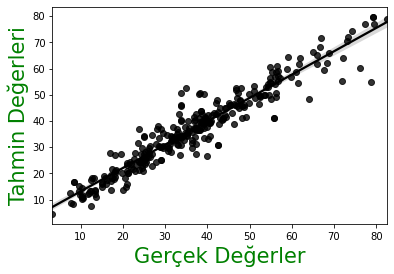

```python
y_hat_opt_xgb = xgb_best.predict(X_test)

fig, ax = mpl.subplots()
sb.regplot(y_test, y_hat_opt_xgb, color="black")
ax.set_ylabel("Tahmin Değerleri", fontsize=21, color="green")
ax.set_xlabel("Gerçek Değerler", fontsize=21, color="green")
```

```python
print(" R2 Değeri: ",r2_score(y_test,y_hat_opt_xgb),"\n","MSE Değeri:",mean_squared_error(y_test,y_hat_opt_xgb))
```

```
 R2 Değeri:  0.9082315374362602
 MSE Değeri: 24.0531746803494
```

### Grafik incelendiğinde, modelin out-of-sample prediction'unun da çok iyi olduğu görülüyor. R2 ve MSE değerleri de çok iyi.

### R2 değerine göre, bağımlı değişkendeki toplam değişimin %90'ı bağımsız değişkenler tarafından açıklanabilmiştir. MSE değerine göre, tahmin edilen değerler gerçek değerlere çok yakındır.

### Modelin performansı çok iyi seviyededir.

```python
r2_degerleri=[r2_score(y_egitim, yhat_OLS),r2_score(y_egitim, yhat_3_PCR),r2_score(y_egitim, yhat_7_PLS),
              r2_score(y_egitim, yhat_ridge),r2_score(y_egitim, yhat_lasso),r2_score(y_egitim, y_hat_5_knn),
             r2_score(y_egitim, y_hat_opt_svr_linear),r2_score(y_egitim, y_hat_opt_2_svr_nonlinear),
              r2_score(y_egitim, best_tahmin_ysa),r2_score(y_egitim,best_tahmin_egitim_cart),
              r2_score(y_egitim,y_tahmin_best_bagg),r2_score(y_egitim,y_tahmin_optimum_rf),r2_score(y_egitim,y_tahmin_best_gb),
              r2_score(y_egitim,y_tahmin_opt_xgb)
             ]
mse_degerleri=[mean_squared_error(y_egitim, yhat_OLS),mean_squared_error(y_egitim, yhat_3_PCR),
               mean_squared_error(y_egitim, yhat_7_PLS),mean_squared_error(y_egitim, yhat_ridge),
               mean_squared_error(y_egitim, yhat_lasso),mean_squared_error(y_egitim, y_hat_5_knn),
              mean_squared_error(y_egitim, y_hat_opt_svr_linear),mean_squared_error(y_egitim, y_hat_opt_2_svr_nonlinear),
              mean_squared_error(y_egitim, best_tahmin_ysa),mean_squared_error(y_egitim,best_tahmin_egitim_cart),
              mean_squared_error(y_egitim,y_tahmin_best_bagg),mean_squared_error(y_egitim,y_tahmin_optimum_rf),
              mean_squared_error(y_egitim,y_tahmin_best_gb),mean_squared_error(y_egitim,y_tahmin_opt_xgb)]
tablo=pd.DataFrame({"Model Türü":["Çoklu Doğrusal Regresyon","Otpimum PCR","Optimum PLS","Ridge","Lasso",
                                  "KNN","Optimum Doğrusal SVR",
                                  "Optimum Doğrusal Olmayan SVR","Optimum Yapay Sinir Ağları","Optimum Karar Ağaçları",
                                  "Optimum Bagging","Optimum Random Forest","Optimum Gradient Boosting","Optimum XGBoost"

                                 ],
                    "R2 Değerleri":r2_degerleri,"MSE Değerleri":mse_degerleri})


r2_degerleri_out=[r2_score(y_test, y_tahmin_OLS),r2_score(y_test, y_tahmin_PCR_6),r2_score(y_test, y_tahmin_7_PLS),
                 r2_score(y_test, y_tahmin_ridge),r2_score(y_test, y_tahmin_lasso),r2_score(y_test, y_tahmin_5_knn),
                  r2_score(y_test, y_tahmin_opt_svr_linear),r2_score(y_test, y_tahmin_opt_2_svr_nonlinear),
                  r2_score(y_test, best_tahmin_test_ysa),r2_score(y_test,best_tahmin_test_cart),r2_score(y_test,y_hat_best_bagg),
                  r2_score(y_test,y_hat_optimum_rf),r2_score(y_test,y_hat_best_gb),r2_score(y_test,y_hat_opt_xgb)]

mse_degerleri_out=[mean_squared_error(y_test, y_tahmin_OLS),mean_squared_error(y_test, y_tahmin_PCR_6),
                   mean_squared_error(y_test, y_tahmin_7_PLS),mean_squared_error(y_test, y_tahmin_ridge),
                  mean_squared_error(y_test, y_tahmin_lasso),mean_squared_error(y_test, y_tahmin_5_knn),
                  mean_squared_error(y_test, y_tahmin_opt_svr_linear),mean_squared_error(y_test, y_tahmin_opt_2_svr_nonlinear),
                  mean_squared_error(y_test, best_tahmin_test_ysa),mean_squared_error(y_test,best_tahmin_test_cart),
                  mean_squared_error(y_test,y_hat_best_bagg),mean_squared_error(y_test,y_hat_optimum_rf),
                  mean_squared_error(y_test,y_hat_best_gb),mean_squared_error(y_test,y_hat_opt_xgb)]

tablo_2=pd.DataFrame({"Model Türü":["Çoklu Doğrusal Regresyon","Otpimum PCR","Optimum PLS","Ridge","Lasso",
                                    "KNN","Optimum Doğrusal SVR",
                                  "Optimum Doğrusal Olmayan SVR","Optimum Yapay Sinir Ağları","Optimum Karar Ağaçları",
                                  "Optimum Bagging","Optimum Random Forest","Optimum Gradient Boosting","Optimum XGBoost"

                                 ],
                    "R2 Değerleri":r2_degerleri_out,"MSE Değerleri":mse_degerleri_out})

print("\n","\t","\t","\t",'\033[1m' + 'IN-SAMPLE PREDICTION DEĞERLERİ',"\t","\t",'\033[1m' + 'OUT-OF-SAMPLE PREDICTION DEĞERLERİ')
pd.concat([tablo,tablo_2],axis=1)
```

```
 	 	 	 IN-SAMPLE PREDICTION DEĞERLERİ 	 	 OUT-OF-SAMPLE PREDICTION DEĞERLERİ
```

|  | Model Türü | R2 Değerleri | MSE Değerleri | Model Türü | R2 Değerleri | MSE Değerleri |
| --- | --- | --- | --- | --- | --- | --- |
| 0 | Çoklu Doğrusal Regresyon | 0.641190 | 102.531948 | Çoklu Doğrusal Regresyon | 0.541481 | 120.181256 |
| 1 | Otpimum PCR | 0.593873 | 116.053055 | Otpimum PCR | 0.515243 | 127.058427 |
| 2 | Optimum PLS | 0.641094 | 102.559188 | Optimum PLS | 0.541921 | 120.065934 |
| 3 | Ridge | 0.641190 | 102.531948 | Ridge | 0.541481 | 120.181225 |
| 4 | Lasso | 0.636448 | 103.886998 | Lasso | 0.542429 | 119.932750 |
| 5 | KNN | 0.818076 | 51.985814 | KNN | 0.621192 | 99.288382 |
| 6 | Optimum Doğrusal SVR | 0.620342 | 108.489257 | Optimum Doğrusal SVR | 0.516536 | 126.719398 |
| 7 | Optimum Doğrusal Olmayan SVR | 0.482879 | 147.770061 | Optimum Doğrusal Olmayan SVR | 0.432128 | 148.843344 |
| 8 | Optimum Yapay Sinir Ağları | 0.974210 | 7.369526 | Optimum Yapay Sinir Ağları | 0.882800 | 30.718979 |
| 9 | Optimum Karar Ağaçları | 0.965260 | 9.927061 | Optimum Karar Ağaçları | 0.781664 | 57.227463 |
| 10 | Optimum Bagging | 0.909907 | 25.744485 | Optimum Bagging | 0.776605 | 58.553511 |
| 11 | Optimum Random Forest | 0.984444 | 4.445199 | Optimum Random Forest | 0.892385 | 28.206746 |
| 12 | Optimum Gradient Boosting | 0.984033 | 4.562712 | Optimum Gradient Boosting | 0.916944 | 21.769620 |
| 13 | Optimum XGBoost | 0.994679 | 1.520466 | Optimum XGBoost | 0.908232 | 24.053175 |

### Her model için in-sample prediction değerlerinden ve out-of-sample prediction değerlerinden elde edilen R2 ve MSE değerlerinin özetlendiği tablodan da görüldüğü üzere, En Küçük Kareler modelinden Doğrusal Olmayan SVR modeline kadar olan tüm modeller tahmin performansında yeterli seviyeye ulaşamadı.

### Geri kalan modellerin in-sample performansları hemen hemen aynı olsa da Karar Ağaçları, Bagging modellerinin out-of-sample performanslarında düşüş oldu. Bir modelden beklentimiz, o modelin daha önce karşılaşmadığı gözlemler üzerinden iyi tahminler yapabilmesi olduğu için aslında biz modelin out-of-sample performansını daha çok önemsiyoruz. Dolayısıyla bu modeller de benim verisetim için optimum model olarak seçilmedi.

### Geriye kalan Yapay Sinir Ağları, Random Forest, Gradient Boosting ve XGBoost modellerinin de in-sample performansları birbirine çok yakın. Out-of-sample performansları incelendiğinde ise Gradient Boosting biraz daha önde gözüküyor. MSE değeri de diğer üç modelin out-of-sample tahminleri üzerinden hesaplanan MSE değerlerine göre daha düşük. Dolayısıyla benim verisetim için optimum model Gradient Boosting modelidir.